# Read files

```python
test = weather_cluster.groupby(['cluster']).mean()
display(test)
```

| cluster | Mean_Temperature_F | Mean_Humidity | Mean_Visibility_Miles | Precipitation_In | count |
| --- | --- | --- | --- | --- | --- |
| 0 | 46.961039 | 79.629870 | 8.733766 | 0.307857 | 146.876623 |
| 1 | 68.725664 | 54.026549 | 9.938053 | 0.003540 | 593.212389 |
| 2 | 52.177489 | 71.926407 | 9.333333 | 0.086970 | 285.207792 |
| 3 | 62.476440 | 63.968586 | 9.806283 | 0.023508 | 421.623037 |

[output not shown]

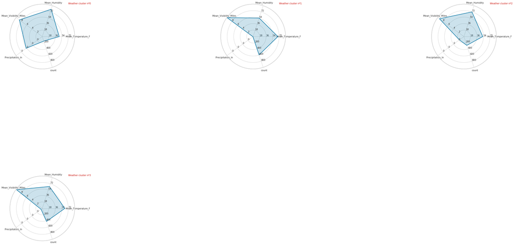

```python
# And here we can visualise the main properties of the clusters using a radar perspective
fig = plt.figure(figsize=(10,12))

attributes = ['Mean_Temperature_F','Mean_Humidity', 'Mean_Visibility_Miles' ,'Precipitation_In', 'count']
n_clusters = 4


ranges = [[0, 90], [0, 90], [0, 10], [0, .5],  [0, 1000]]
index  = [0, 1, 2, 3, 4, 5]

n_groups = 6 ; i_cols = 2
i_rows = n_groups//i_cols
size_x, size_y = (1.5/i_cols), (1/i_rows)

for ind in range(n_clusters):
    ix = ind%3 ; iy = i_rows - ind//3
    pos_x = ix*(size_x + 0.55) ; pos_y = iy*(size_y + 0.55)
    location = [pos_x, pos_y]  ; sizes = [size_x, size_y]
    #______________________________________________________
    data_nr = np.array(test.loc[index[ind], attributes])
    radar = RadarChart(fig, location, sizes, attributes, ranges)
    radar.plot(data_nr, color = 'b', linewidth=2.0)
    radar.fill(data_nr, alpha = 0.2, color = 'b')
    radar.title(title = 'Weather cluster nº{}'.format(index[ind]), color = 'r')
    ind += 1
```

[output not shown]

1. We will try a more scientific approach, trying to calculate hourly temperatures, based on this paper:
   - https://sci-hub.tw/https://www.sciencedirect.com/science/article/pii/0168192389900646
   - https://www.researchgate.net/publication/245383326_New_algorithm_for_generating_hourly_temperature_values_using_daily_maximum_minimum_and_average_values_from_climate_models

```python
from math import pi, sin, cos, asin, exp

def calc_day_length(doy, yr_days, latitude):

        """
        Daylength in hours
        Eqns come from Leuning A4, A5 and A6, pg. 1196
        Reference:
        ----------
        Leuning et al (1995) Plant, Cell and Environment, 18, 1183-1200.
        Parameters:
        -----------
        doy : int
            day of year, 1=jan 1
        yr_days : int
            number of days in a year, 365 or 366
        latitude : float
            latitude [degrees]
        Returns:
        --------
        dayl : float
            daylength [hrs]
        """

        deg2rad = pi / 180.0;
        rlat = latitude * deg2rad;
        sindec = -sin(23.5 * deg2rad) * cos(2.0 * pi * (doy + 10.0) / yr_days);
        a = sin(rlat) * sindec;
        b = cos(rlat) * cos(asin(sindec));

        return 12.0 * (1.0 + (2.0 / pi) * asin(a / b))


def estimate_diurnal_temp(doy, tmin, tmax, latitude):
        """
        Calculate diurnal temperature following Parton and Logan
        the day is divided into two segments and using a truncated sine wave
        in the daylight and an exponential decrease in temperature
        at night.
        TO DO:
        - Hours between 00:00 and sunrise should be modelled using the previous
          days information.
        Arguments:
        ----------
        tmin : double
            day minimum temp (deg C)
        tmax : float
            day maximum temp (deg C)
        References:
        ----------
        * Parton and Logan (1981) A model for dirunal variation in soil and
           air temperature. Agricultural Meteorology, 23, 205--216.
        * Kimball and Bellamy (1986) Energy in Agriculture, 5, 185-197.
        """
        # 1.5 m air temperature values from Parton and Logan, table 1
        a = 1.86
        b = 2.2     # nighttime coeffcient
        c = -0.17   # lag of the min temp from the time of runrise

        day_length = calc_day_length(doy, 365, latitude)

        night_length = 24 - day_length

        sunrise = 12.0 - day_length / 2.0 + c
        sunset = 12.0 + day_length / 2.0

        # temperature at sunset
        m = sunset - sunrise + c
        tset = (tmax - tmin) * sin(pi * m / (day_length + 2.0 * a)) + tmin

        tday = np.zeros(24)
        for i in range(1, 24+1):
            hour = i / 2.0

            # hour - time of the minimum temperature (accounting for lag time)
            m = hour - sunrise + c
            if hour >= sunrise and hour <= sunset:
                tday[i-1] = tmin + (tmax - tmin) * \
                            sin((pi * m) / (day_length + 2.0 * a))
            else:
                if hour > sunset:
                    n = hour - sunset
                elif hour < sunrise:
                    n = (24.0 + hour) - sunset


                d = (tset - tmin) / (exp(b) - 1.0)

                # includes missing displacement to allow T to reach Tmin, this
                # removes a discontinuity in the original Parton and Logan eqn.
                # See Kimball and Bellamy (1986) Energy in Agriculture, 5,
                # 185-197
                tday[i-1] = (tmin -d) + (tset - tmin - d) * \
                            exp(-b * n / (night_length + c))

        return (tday)
```

```python
# Now let's build a function that given a day, tmin, tmax and an hour calculates the temp
# please note 24 = 0
def hourly_temp(doy, tmin, tmax, latitude, hour ):
    base_temp = estimate_diurnal_temp(doy=doy, tmin=tmin, tmax=tmax, latitude=latitude)
    return base_temp[hour]

Seattle_lat = 47.61
#example for day 1, with min temp=10, max temp = 12, for a latitude and at 10:00 AM
print (hourly_temp(1, 10, 12, Seattle_lat, 10))
```

```
10.012427602265275
```

```python
#finally our weather dataframe will contain the cluster
weather['cluster'] = weather_cluster['cluster']
display(weather.head(10))
```

|  | Date | Max_Temperature_F | Mean_Temperature_F | Min_TemperatureF | Max_Dew_Point_F | MeanDew_Point_F | Min_Dewpoint_F | Max_Humidity | Mean_Humidity | Min_Humidity | ... | Max_Wind_Speed_MPH | Mean_Wind_Speed_MPH | Max_Gust_Speed_MPH | Precipitation_In | year | month | day | count | events_le | cluster |
| --- | --- | --- | --- | --- | --- | --- | --- | --- | --- | --- | --- | --- | --- | --- | --- | --- | --- | --- | --- | --- | --- |
| 0 | 2014-10-13 | 71 | 62.0 | 54 | 55 | 51 | 46 | 87 | 68 | 46 | ... | 13 | 4 | 21 | 0.00 | 2014 | 10 | 13 | 409 | 3 | 3 |
| 1 | 2014-10-14 | 63 | 59.0 | 55 | 52 | 51 | 50 | 88 | 78 | 63 | ... | 10 | 5 | 17 | 0.11 | 2014 | 10 | 14 | 491 | 3 | 3 |
| 2 | 2014-10-15 | 62 | 58.0 | 54 | 53 | 50 | 46 | 87 | 77 | 67 | ... | 18 | 7 | 25 | 0.45 | 2014 | 10 | 15 | 313 | 3 | 2 |
| 3 | 2014-10-16 | 71 | 61.0 | 52 | 49 | 46 | 42 | 83 | 61 | 36 | ... | 9 | 4 | - | 0.00 | 2014 | 10 | 16 | 395 | 3 | 3 |
| 4 | 2014-10-17 | 64 | 60.0 | 57 | 55 | 51 | 41 | 87 | 72 | 46 | ... | 8 | 3 | - | 0.14 | 2014 | 10 | 17 | 294 | 3 | 2 |
| 5 | 2014-10-18 | 68 | 64.0 | 59 | 59 | 57 | 55 | 90 | 83 | 68 | ... | 10 | 4 | - | 0.31 | 2014 | 10 | 18 | 399 | 3 | 3 |
| 6 | 2014-10-19 | 73 | 64.0 | 55 | 57 | 55 | 53 | 94 | 74 | 52 | ... | 10 | 3 | 18 | 0.00 | 2014 | 10 | 19 | 666 | 3 | 1 |
| 7 | 2014-10-20 | 66 | 60.0 | 55 | 57 | 54 | 50 | 90 | 78 | 67 | ... | 12 | 5 | - | 0.44 | 2014 | 10 | 20 | 389 | 3 | 3 |
| 8 | 2014-10-21 | 64 | 58.0 | 55 | 52 | 49 | 46 | 87 | 70 | 58 | ... | 15 | 8 | 21 | 0.10 | 2014 | 10 | 21 | 357 | 3 | 3 |
| 9 | 2014-10-22 | 60 | 58.0 | 57 | 55 | 53 | 48 | 88 | 81 | 67 | ... | 14 | 8 | 22 | 1.43 | 2014 | 10 | 22 | 141 | 3 | 0 |

10 rows × 26 columns

Now we have two ways to add the temperature, or by type of the day(cluster), or by the hourly temperature(calculated by hourly_temp)

# Investigating trips

```python
# we will assume a hourly time, even that we should try different time intervals, like 15 min, 30 min, or even detect time bins like morning, afternoon, lunch time...
trips_test = trips[['trip_id', 'starttime','from_station_id']].copy()
trips_test['Date'] = trips_test['starttime'].dt.floor('h')
trips_agg = trips_test.groupby(['Date', 'from_station_id'])['trip_id'].count().to_frame().reset_index()
display(trips_agg.head(10))
```

|  | Date | from_station_id | trip_id |
| --- | --- | --- | --- |
| 0 | 2014-10-13 10:00:00 | CBD-06 | 6 |
| 1 | 2014-10-13 11:00:00 | CBD-05 | 1 |
| 2 | 2014-10-13 11:00:00 | CBD-07 | 1 |
| 3 | 2014-10-13 11:00:00 | CH-02 | 3 |
| 4 | 2014-10-13 11:00:00 | DPD-01 | 1 |
| 5 | 2014-10-13 11:00:00 | PS-04 | 44 |
| 6 | 2014-10-13 11:00:00 | PS-05 | 4 |
| 7 | 2014-10-13 12:00:00 | BT-03 | 2 |
| 8 | 2014-10-13 12:00:00 | BT-04 | 3 |
| 9 | 2014-10-13 12:00:00 | CBD-05 | 2 |

```python
# work on the feature date
trips_agg['date']=trips_agg['Date'].dt.date
trips_agg['hour']=trips_agg['Date'].dt.hour
trips_agg['month']=trips_agg['Date'].dt.month
trips_agg['day']=trips_agg['Date'].dt.day
trips_agg['year']=trips_agg['Date'].dt.year
trips_agg['dow']=trips_agg['Date'].dt.dayofweek
trips_agg['weekend'] = (trips_agg['dow'] >4).astype(int)
trips_agg['working_day'] = (trips_agg['dow'] <5).astype(int)
# we need this to use the function to calculate the hourly temperature
trips_agg['doy'] = trips_agg['Date'].dt.dayofyear
display(trips_agg.head(10))
```

|  | Date | from_station_id | trip_id | date | hour | month | day | year | dow | weekend | working_day | doy |
| --- | --- | --- | --- | --- | --- | --- | --- | --- | --- | --- | --- | --- |
| 0 | 2014-10-13 10:00:00 | CBD-06 | 6 | 2014-10-13 | 10 | 10 | 13 | 2014 | 0 | 0 | 1 | 286 |
| 1 | 2014-10-13 11:00:00 | CBD-05 | 1 | 2014-10-13 | 11 | 10 | 13 | 2014 | 0 | 0 | 1 | 286 |
| 2 | 2014-10-13 11:00:00 | CBD-07 | 1 | 2014-10-13 | 11 | 10 | 13 | 2014 | 0 | 0 | 1 | 286 |
| 3 | 2014-10-13 11:00:00 | CH-02 | 3 | 2014-10-13 | 11 | 10 | 13 | 2014 | 0 | 0 | 1 | 286 |
| 4 | 2014-10-13 11:00:00 | DPD-01 | 1 | 2014-10-13 | 11 | 10 | 13 | 2014 | 0 | 0 | 1 | 286 |
| 5 | 2014-10-13 11:00:00 | PS-04 | 44 | 2014-10-13 | 11 | 10 | 13 | 2014 | 0 | 0 | 1 | 286 |
| 6 | 2014-10-13 11:00:00 | PS-05 | 4 | 2014-10-13 | 11 | 10 | 13 | 2014 | 0 | 0 | 1 | 286 |
| 7 | 2014-10-13 12:00:00 | BT-03 | 2 | 2014-10-13 | 12 | 10 | 13 | 2014 | 0 | 0 | 1 | 286 |
| 8 | 2014-10-13 12:00:00 | BT-04 | 3 | 2014-10-13 | 12 | 10 | 13 | 2014 | 0 | 0 | 1 | 286 |
| 9 | 2014-10-13 12:00:00 | CBD-05 | 2 | 2014-10-13 | 12 | 10 | 13 | 2014 | 0 | 0 | 1 | 286 |

```python
# add the min, max and cluster for the day
final_trip = pd.concat([trips_agg, weather[[ 'cluster', 'Max_Temperature_F','Min_TemperatureF']]],  axis=1)
# add the hourly temperature
final_trip['temp_calc'] = final_trip.apply(lambda row: hourly_temp(row['doy'], row['Min_TemperatureF'], row['Max_Temperature_F'], Seattle_lat, row['hour']), axis=1)
display(final_trip.head(10))
```

|  | Date | from_station_id | trip_id | date | hour | month | day | year | dow | weekend | working_day | doy | cluster | Max_Temperature_F | Min_TemperatureF | temp_calc |
| --- | --- | --- | --- | --- | --- | --- | --- | --- | --- | --- | --- | --- | --- | --- | --- | --- |
| 0 | 2014-10-13 10:00:00 | CBD-06 | 6 | 2014-10-13 | 10 | 10 | 13 | 2014 | 0 | 0 | 1 | 286 | 3.0 | 71.0 | 54.0 | 53.869980 |
| 1 | 2014-10-13 11:00:00 | CBD-05 | 1 | 2014-10-13 | 11 | 10 | 13 | 2014 | 0 | 0 | 1 | 286 | 3.0 | 63.0 | 55.0 | 54.885655 |
| 2 | 2014-10-13 11:00:00 | CBD-07 | 1 | 2014-10-13 | 11 | 10 | 13 | 2014 | 0 | 0 | 1 | 286 | 2.0 | 62.0 | 54.0 | 53.885655 |
| 3 | 2014-10-13 11:00:00 | CH-02 | 3 | 2014-10-13 | 11 | 10 | 13 | 2014 | 0 | 0 | 1 | 286 | 3.0 | 71.0 | 52.0 | 51.728431 |
| 4 | 2014-10-13 11:00:00 | DPD-01 | 1 | 2014-10-13 | 11 | 10 | 13 | 2014 | 0 | 0 | 1 | 286 | 2.0 | 64.0 | 57.0 | 56.899948 |
| 5 | 2014-10-13 11:00:00 | PS-04 | 44 | 2014-10-13 | 11 | 10 | 13 | 2014 | 0 | 0 | 1 | 286 | 3.0 | 68.0 | 59.0 | 58.871362 |
| 6 | 2014-10-13 11:00:00 | PS-05 | 4 | 2014-10-13 | 11 | 10 | 13 | 2014 | 0 | 0 | 1 | 286 | 1.0 | 73.0 | 55.0 | 54.742724 |
| 7 | 2014-10-13 12:00:00 | BT-03 | 2 | 2014-10-13 | 12 | 10 | 13 | 2014 | 0 | 0 | 1 | 286 | 3.0 | 66.0 | 55.0 | 54.680765 |
| 8 | 2014-10-13 12:00:00 | BT-04 | 3 | 2014-10-13 | 12 | 10 | 13 | 2014 | 0 | 0 | 1 | 286 | 3.0 | 64.0 | 55.0 | 54.738808 |
| 9 | 2014-10-13 12:00:00 | CBD-05 | 2 | 2014-10-13 | 12 | 10 | 13 | 2014 | 0 | 0 | 1 | 286 | 0.0 | 60.0 | 57.0 | 56.912936 |

```python
# we can try to use fbprophet, if we are too lazy to do it by hand, or we can try some simple methods with gridsearch
```

# Using FBProphet

- https://facebook.github.io/prophet/docs/quick_start.html

```python
# in order to use FBProphet we only can use DS and Y columns, so we need to iterate for each station and use the total of rides for each time
# obvioulsy this will only have in attention trend and seasonlaity, even we can add other hyper paremeters
from fbprophet import Prophet
from fbprophet.diagnostics import cross_validation, performance_metrics


stations = final_trip['from_station_id'].unique()
print (stations)
for station in ['BT-01']:
    print (station)
    fp_forecast = final_trip[['date','trip_id']][final_trip['from_station_id']==station]
    fp_forecast.columns = ['ds', 'y']
    m = Prophet(yearly_seasonality=True)
    m.fit(fp_forecast)
    future = m.make_future_dataframe(periods=365, freq='d')
    display(future.tail())
    forecast = m.predict(future)
    forecast[['ds', 'yhat', 'yhat_lower', 'yhat_upper']].tail()

    fig1 = m.plot(forecast)
    fig2 = m.plot_components(forecast)
    display(forecast[['ds',   'yhat', 'yhat_lower', 'yhat_upper']].head(10))
    df_cv = cross_validation(m, initial='180 days', period='180 days', horizon='180 days')
    display(df_cv.head(n=10))
    df_p = performance_metrics(df_cv)
    display(df_p.head())
    break

# where the black points are the real values, the dark blue the predict values and the light blue the uncertainty intervals.
```

```
INFO:fbprophet:Disabling daily seasonality. Run prophet with daily_seasonality=True to override this.
```

```
['CBD-06' 'CBD-05' 'CBD-07' 'CH-02' 'DPD-01' 'PS-04' 'PS-05' 'BT-03'
 'BT-04' 'CBD-13' 'FH-01' 'ID-04' 'UD-01' 'UD-02' 'UD-04' 'UW-02' 'UW-07'
 'WF-04' 'BT-05' 'CBD-03' 'CH-05' 'CH-08' 'CH-09' 'CH-15' 'DPD-03'
 'SLU-01' 'SLU-02' 'SLU-15' 'SLU-18' 'SLU-19' 'UD-07' 'UW-10' 'WF-01'
 'CH-07' 'SLU-17' 'UW-04' 'UW-06' 'BT-01' 'CH-06' 'EL-01' 'EL-05' 'SLU-04'
 'CH-01' 'CH-03' 'CH-12' 'EL-03' 'FH-04' 'SLU-07' 'SLU-16' 'UW-01' 'CD-01'
 'Pronto shop' 'SLU-20' 'CBD-04' 'SLU-21' 'UW-11' 'CH-16' 'Pronto shop 2'
 'SLU-22' 'WF-03' '8D OPS 02']
BT-01
```

[output not shown]

```python
viz_df = fp_forecast.join(forecast[['yhat', 'yhat_lower','yhat_upper']]).reset_index()
ax = sns.lineplot(x="ds", y="y", data=viz_df)
display(viz_df.head())
```

# Using a Linear regression

```python
display(final_trip.head(10))
```

|  | Date | from_station_id | trip_id | date | hour | month | day | year | dow | weekend | working_day | doy | cluster | Max_Temperature_F | Min_TemperatureF | temp_calc |
| --- | --- | --- | --- | --- | --- | --- | --- | --- | --- | --- | --- | --- | --- | --- | --- | --- |
| 0 | 2014-10-13 10:00:00 | CBD-06 | 6 | 2014-10-13 | 10 | 10 | 13 | 2014 | 0 | 0 | 1 | 286 | 3.0 | 71.0 | 54.0 | 53.869980 |
| 1 | 2014-10-13 11:00:00 | CBD-05 | 1 | 2014-10-13 | 11 | 10 | 13 | 2014 | 0 | 0 | 1 | 286 | 3.0 | 63.0 | 55.0 | 54.885655 |
| 2 | 2014-10-13 11:00:00 | CBD-07 | 1 | 2014-10-13 | 11 | 10 | 13 | 2014 | 0 | 0 | 1 | 286 | 2.0 | 62.0 | 54.0 | 53.885655 |
| 3 | 2014-10-13 11:00:00 | CH-02 | 3 | 2014-10-13 | 11 | 10 | 13 | 2014 | 0 | 0 | 1 | 286 | 3.0 | 71.0 | 52.0 | 51.728431 |
| 4 | 2014-10-13 11:00:00 | DPD-01 | 1 | 2014-10-13 | 11 | 10 | 13 | 2014 | 0 | 0 | 1 | 286 | 2.0 | 64.0 | 57.0 | 56.899948 |
| 5 | 2014-10-13 11:00:00 | PS-04 | 44 | 2014-10-13 | 11 | 10 | 13 | 2014 | 0 | 0 | 1 | 286 | 3.0 | 68.0 | 59.0 | 58.871362 |
| 6 | 2014-10-13 11:00:00 | PS-05 | 4 | 2014-10-13 | 11 | 10 | 13 | 2014 | 0 | 0 | 1 | 286 | 1.0 | 73.0 | 55.0 | 54.742724 |
| 7 | 2014-10-13 12:00:00 | BT-03 | 2 | 2014-10-13 | 12 | 10 | 13 | 2014 | 0 | 0 | 1 | 286 | 3.0 | 66.0 | 55.0 | 54.680765 |
| 8 | 2014-10-13 12:00:00 | BT-04 | 3 | 2014-10-13 | 12 | 10 | 13 | 2014 | 0 | 0 | 1 | 286 | 3.0 | 64.0 | 55.0 | 54.738808 |
| 9 | 2014-10-13 12:00:00 | CBD-05 | 2 | 2014-10-13 | 12 | 10 | 13 | 2014 | 0 | 0 | 1 | 286 | 0.0 | 60.0 | 57.0 | 56.912936 |

```python
# we will consider the following collumns
columns = ['from_station_id', 'hour', 'month', 'day', 'year', 'dow', 'weekend', 'working_day', 'doy', 'cluster', 'temp_calc', 'trip_id']
regression = final_trip[columns].copy()
print(regression.columns)
```

```
Index(['from_station_id', 'hour', 'month', 'day', 'year', 'dow', 'weekend',
       'working_day', 'doy', 'cluster', 'temp_calc', 'trip_id'],
      dtype='object')
```

```python
# we need to deal with  categorical features: from_station_id
regression = pd.get_dummies(data=regression, columns=['from_station_id'])
display(regression.head(10))
```

|  | hour | month | day | year | dow | weekend | working_day | doy | cluster | temp_calc | ... | from_station_id_UW-01 | from_station_id_UW-02 | from_station_id_UW-04 | from_station_id_UW-06 | from_station_id_UW-07 | from_station_id_UW-10 | from_station_id_UW-11 | from_station_id_WF-01 | from_station_id_WF-03 | from_station_id_WF-04 |
| --- | --- | --- | --- | --- | --- | --- | --- | --- | --- | --- | --- | --- | --- | --- | --- | --- | --- | --- | --- | --- | --- |
| 0 | 10 | 10 | 13 | 2014 | 0 | 0 | 1 | 286 | 3.0 | 53.869980 | ... | 0 | 0 | 0 | 0 | 0 | 0 | 0 | 0 | 0 | 0 |
| 1 | 11 | 10 | 13 | 2014 | 0 | 0 | 1 | 286 | 3.0 | 54.885655 | ... | 0 | 0 | 0 | 0 | 0 | 0 | 0 | 0 | 0 | 0 |
| 2 | 11 | 10 | 13 | 2014 | 0 | 0 | 1 | 286 | 2.0 | 53.885655 | ... | 0 | 0 | 0 | 0 | 0 | 0 | 0 | 0 | 0 | 0 |
| 3 | 11 | 10 | 13 | 2014 | 0 | 0 | 1 | 286 | 3.0 | 51.728431 | ... | 0 | 0 | 0 | 0 | 0 | 0 | 0 | 0 | 0 | 0 |
| 4 | 11 | 10 | 13 | 2014 | 0 | 0 | 1 | 286 | 2.0 | 56.899948 | ... | 0 | 0 | 0 | 0 | 0 | 0 | 0 | 0 | 0 | 0 |
| 5 | 11 | 10 | 13 | 2014 | 0 | 0 | 1 | 286 | 3.0 | 58.871362 | ... | 0 | 0 | 0 | 0 | 0 | 0 | 0 | 0 | 0 | 0 |
| 6 | 11 | 10 | 13 | 2014 | 0 | 0 | 1 | 286 | 1.0 | 54.742724 | ... | 0 | 0 | 0 | 0 | 0 | 0 | 0 | 0 | 0 | 0 |
| 7 | 12 | 10 | 13 | 2014 | 0 | 0 | 1 | 286 | 3.0 | 54.680765 | ... | 0 | 0 | 0 | 0 | 0 | 0 | 0 | 0 | 0 | 0 |
| 8 | 12 | 10 | 13 | 2014 | 0 | 0 | 1 | 286 | 3.0 | 54.738808 | ... | 0 | 0 | 0 | 0 | 0 | 0 | 0 | 0 | 0 | 0 |
| 9 | 12 | 10 | 13 | 2014 | 0 | 0 | 1 | 286 | 0.0 | 56.912936 | ... | 0 | 0 | 0 | 0 | 0 | 0 | 0 | 0 | 0 | 0 |

10 rows × 72 columns

```
Index(['hour', 'month', 'day', 'year', 'dow', 'weekend', 'working_day', 'doy',
       'cluster', 'temp_calc', 'trip_id', 'from_station_id_8D OPS 02',
       'from_station_id_BT-01', 'from_station_id_BT-03',
       'from_station_id_BT-04', 'from_station_id_BT-05',
       'from_station_id_CBD-03', 'from_station_id_CBD-04',
       'from_station_id_CBD-05', 'from_station_id_CBD-06',
       'from_station_id_CBD-07', 'from_station_id_CBD-13',
       'from_station_id_CD-01', 'from_station_id_CH-01',
       'from_station_id_CH-02', 'from_station_id_CH-03',
       'from_station_id_CH-05', 'from_station_id_CH-06',
       'from_station_id_CH-07', 'from_station_id_CH-08',
       'from_station_id_CH-09', 'from_station_id_CH-12',
       'from_station_id_CH-15', 'from_station_id_CH-16',
       'from_station_id_DPD-01', 'from_station_id_DPD-03',
       'from_station_id_EL-01', 'from_station_id_EL-03',
       'from_station_id_EL-05', 'from_station_id_FH-01',
       'from_station_id_FH-04', 'from_station_id_ID-04',
       'from_station_id_PS-04', 'from_station_id_PS-05',
       'from_station_id_Pronto shop', 'from_station_id_Pronto shop 2',
       'from_station_id_SLU-01', 'from_station_id_SLU-02',
       'from_station_id_SLU-04', 'from_station_id_SLU-07',
       'from_station_id_SLU-15', 'from_station_id_SLU-16',
       'from_station_id_SLU-17', 'from_station_id_SLU-18',
       'from_station_id_SLU-19', 'from_station_id_SLU-20',
       'from_station_id_SLU-21', 'from_station_id_SLU-22',
       'from_station_id_UD-01', 'from_station_id_UD-02',
       'from_station_id_UD-04', 'from_station_id_UD-07',
       'from_station_id_UW-01', 'from_station_id_UW-02',
       'from_station_id_UW-04', 'from_station_id_UW-06',
       'from_station_id_UW-07', 'from_station_id_UW-10',
       'from_station_id_UW-11', 'from_station_id_WF-01',
       'from_station_id_WF-03', 'from_station_id_WF-04'],
      dtype='object')
```

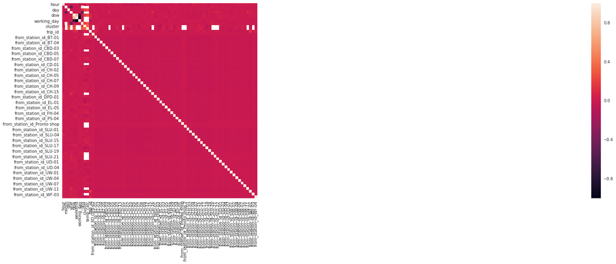

```python
#let's have a look on the correlation matrix and check what features are not relevante for the regression
regression_corr = regression.corr()
f, ax = plt.subplots(figsize=(300, 9))
# Generate a custom diverging colormap
sns.heatmap(regression_corr,square=True, )

print (regression.columns)
```

```python
# We do not see may dependent features, so let's use them all
from sklearn.linear_model import LinearRegression
from sklearn.model_selection import train_test_split
from sklearn.metrics import mean_squared_error, r2_score, precision_recall_fscore_support as score, f1_score

#drop all nan
regression_filter= regression.dropna(how='any')

X = regression_filter[[ 'hour', 'month', 'day', 'year', 'dow', 'weekend', 'working_day', 'doy', 'cluster', 'temp_calc', 'from_station_id_8D OPS 02',
       'from_station_id_BT-01', 'from_station_id_BT-03',
       'from_station_id_BT-04', 'from_station_id_BT-05',
       'from_station_id_CBD-03', 'from_station_id_CBD-04',
       'from_station_id_CBD-05', 'from_station_id_CBD-06',
       'from_station_id_CBD-07', 'from_station_id_CBD-13',
       'from_station_id_CD-01', 'from_station_id_CH-01',
       'from_station_id_CH-02', 'from_station_id_CH-03',
       'from_station_id_CH-05', 'from_station_id_CH-06',
       'from_station_id_CH-07', 'from_station_id_CH-08',
       'from_station_id_CH-09', 'from_station_id_CH-12',
       'from_station_id_CH-15', 'from_station_id_CH-16',
       'from_station_id_DPD-01', 'from_station_id_DPD-03',
       'from_station_id_EL-01', 'from_station_id_EL-03',
       'from_station_id_EL-05', 'from_station_id_FH-01',
       'from_station_id_FH-04', 'from_station_id_ID-04',
       'from_station_id_PS-04', 'from_station_id_PS-05',
       'from_station_id_Pronto shop', 'from_station_id_Pronto shop 2',
       'from_station_id_SLU-01', 'from_station_id_SLU-02',
       'from_station_id_SLU-04', 'from_station_id_SLU-07',
       'from_station_id_SLU-15', 'from_station_id_SLU-16',
       'from_station_id_SLU-17', 'from_station_id_SLU-18',
       'from_station_id_SLU-19', 'from_station_id_SLU-20',
       'from_station_id_SLU-21', 'from_station_id_SLU-22',
       'from_station_id_UD-01', 'from_station_id_UD-02',
       'from_station_id_UD-04', 'from_station_id_UD-07',
       'from_station_id_UW-01', 'from_station_id_UW-02',
       'from_station_id_UW-04', 'from_station_id_UW-06',
       'from_station_id_UW-07', 'from_station_id_UW-10',
       'from_station_id_UW-11', 'from_station_id_WF-01',
       'from_station_id_WF-03', 'from_station_id_WF-04']]
Y =regression_filter[['trip_id']]



#X_train, X_test, y_train, y_test = train_test_split(X, Y, test_size=0.2)
#lr = LinearRegression(copy_X=True, fit_intercept=True, normalize=False)
#lr.fit(X_train, y_train)
#predictions = lr.predict(X_test)
# The coefficients
#print('Coefficients: \n', lr.coef_)
# The mean squared error
#print("Mean squared error: %.2f"
#      % mean_squared_error(y_test, predictions))
# Explained variance score: 1 is perfect prediction
#print('Variance score: %.2f' % r2_score(y_test, predictions))
```

[output not shown]

```python
import statsmodels.api as sm # import statsmodels
model = sm.OLS(Y, X).fit()
#predictions = model.predict(X)
# Print out the statistics
model.summary()
```

OLS Regression Results

| Dep. Variable: | trip_id | R-squared: | 0.094 |
| --- | --- | --- | --- |
| Model: | OLS | Adj. R-squared: | 0.018 |
| Method: | Least Squares | F-statistic: | 1.244 |
| Date: | Thu, 21 Mar 2019 | Prob (F-statistic): | 0.121 |
| Time: | 11:49:44 | Log-Likelihood: | -1429.1 |
| No. Observations: | 689 | AIC: | 2966. |
| Df Residuals: | 635 | BIC: | 3211. |
| Df Model: | 53 |  |  |
| Covariance Type: | nonrobust |  |  |

|  | coef | std err | t | P>\|t\| | [0.025 | 0.975] |
| --- | --- | --- | --- | --- | --- | --- |
| hour | -0.0168 | 0.021 | -0.819 | 0.413 | -0.057 | 0.024 |
| month | 0.0001 | 2.8e-05 | 3.574 | 0.000 | 4.51e-05 | 0.000 |
| day | -0.1327 | 0.038 | -3.451 | 0.001 | -0.208 | -0.057 |
| year | 0.0201 | 0.006 | 3.574 | 0.000 | 0.009 | 0.031 |
| dow | -0.1329 | 0.038 | -3.452 | 0.001 | -0.208 | -0.057 |
| weekend | 2.77e-16 | 9.86e-16 | 0.281 | 0.779 | -1.66e-15 | 2.21e-15 |
| working_day | 1e-05 | 2.8e-06 | 3.574 | 0.000 | 4.51e-06 | 1.55e-05 |
| doy | -0.1300 | 0.038 | -3.449 | 0.001 | -0.204 | -0.056 |
| cluster | 0.1107 | 0.077 | 1.432 | 0.153 | -0.041 | 0.263 |
| temp_calc | 0.0073 | 0.009 | 0.767 | 0.443 | -0.011 | 0.026 |
| from_station_id_8D OPS 02 | 3.516e-16 | 5.65e-16 | 0.623 | 0.534 | -7.57e-16 | 1.46e-15 |
| from_station_id_BT-01 | 0.1297 | 0.501 | 0.259 | 0.796 | -0.854 | 1.114 |
| from_station_id_BT-03 | -0.0510 | 0.553 | -0.092 | 0.927 | -1.136 | 1.034 |
| from_station_id_BT-04 | 0.1863 | 0.486 | 0.383 | 0.702 | -0.768 | 1.141 |
| from_station_id_BT-05 | -0.5327 | 0.663 | -0.803 | 0.422 | -1.835 | 0.770 |
| from_station_id_CBD-03 | 0.1772 | 0.501 | 0.354 | 0.724 | -0.807 | 1.161 |
| from_station_id_CBD-04 | 6.815e-16 | 3.98e-16 | 1.713 | 0.087 | -9.98e-17 | 1.46e-15 |
| from_station_id_CBD-05 | 0.5290 | 0.473 | 1.118 | 0.264 | -0.400 | 1.458 |
| from_station_id_CBD-06 | 0.7966 | 0.439 | 1.815 | 0.070 | -0.065 | 1.659 |
| from_station_id_CBD-07 | 0.0382 | 0.450 | 0.085 | 0.932 | -0.845 | 0.922 |
| from_station_id_CBD-13 | 0.0218 | 0.439 | 0.050 | 0.960 | -0.839 | 0.883 |
| from_station_id_CD-01 | 1.909e-16 | 3.29e-16 | 0.580 | 0.562 | -4.56e-16 | 8.38e-16 |
| from_station_id_CH-01 | -0.3943 | 0.516 | -0.764 | 0.445 | -1.408 | 0.619 |
| from_station_id_CH-02 | 0.3634 | 0.385 | 0.945 | 0.345 | -0.392 | 1.119 |
| from_station_id_CH-03 | -0.1424 | 0.555 | -0.257 | 0.797 | -1.231 | 0.946 |
| from_station_id_CH-05 | -0.1830 | 0.450 | -0.407 | 0.684 | -1.066 | 0.700 |
| from_station_id_CH-06 | -0.4459 | 0.600 | -0.744 | 0.457 | -1.623 | 0.731 |
| from_station_id_CH-07 | -0.1956 | 0.440 | -0.445 | 0.657 | -1.060 | 0.668 |
| from_station_id_CH-08 | 0.2850 | 0.440 | 0.648 | 0.517 | -0.578 | 1.148 |
| from_station_id_CH-09 | -0.3651 | 0.517 | -0.706 | 0.480 | -1.380 | 0.650 |
| from_station_id_CH-12 | -0.1096 | 0.500 | -0.219 | 0.827 | -1.092 | 0.873 |
| from_station_id_CH-15 | -0.1454 | 0.555 | -0.262 | 0.793 | -1.235 | 0.945 |
| from_station_id_CH-16 | 7.022e-17 | 2.45e-16 | 0.287 | 0.774 | -4.1e-16 | 5.51e-16 |
| from_station_id_DPD-01 | -0.5189 | 0.575 | -0.902 | 0.367 | -1.648 | 0.610 |
| from_station_id_DPD-03 | -0.3613 | 0.752 | -0.480 | 0.631 | -1.838 | 1.116 |
| from_station_id_EL-01 | 0.1750 | 0.994 | 0.176 | 0.860 | -1.777 | 2.127 |
| from_station_id_EL-03 | -0.1837 | 0.703 | -0.261 | 0.794 | -1.564 | 1.197 |
| from_station_id_EL-05 | -0.0142 | 0.663 | -0.021 | 0.983 | -1.317 | 1.288 |
| from_station_id_FH-01 | -0.2481 | 0.439 | -0.566 | 0.572 | -1.109 | 0.613 |
| from_station_id_FH-04 | -0.5428 | 0.630 | -0.862 | 0.389 | -1.779 | 0.694 |
| from_station_id_ID-04 | -0.0087 | 0.518 | -0.017 | 0.987 | -1.025 | 1.008 |
| from_station_id_PS-04 | 2.3323 | 0.412 | 5.663 | 0.000 | 1.524 | 3.141 |
| from_station_id_PS-05 | -0.0710 | 0.518 | -0.137 | 0.891 | -1.087 | 0.945 |
| from_station_id_Pronto shop | 3.6e-17 | 2.82e-16 | 0.128 | 0.898 | -5.17e-16 | 5.89e-16 |
| from_station_id_Pronto shop 2 | -1.07e-17 | 2.91e-16 | -0.037 | 0.971 | -5.83e-16 | 5.62e-16 |
| from_station_id_SLU-01 | 0.2813 | 0.412 | 0.683 | 0.495 | -0.528 | 1.090 |
| from_station_id_SLU-02 | -0.3635 | 0.554 | -0.657 | 0.512 | -1.451 | 0.724 |
| from_station_id_SLU-04 | 0.0105 | 0.487 | 0.021 | 0.983 | -0.946 | 0.966 |
| from_station_id_SLU-07 | 0.3104 | 0.535 | 0.581 | 0.562 | -0.739 | 1.360 |
| from_station_id_SLU-15 | 0.2677 | 0.461 | 0.581 | 0.561 | -0.637 | 1.172 |
| from_station_id_SLU-16 | -0.0716 | 0.518 | -0.138 | 0.890 | -1.088 | 0.945 |
| from_station_id_SLU-17 | 0.6049 | 0.576 | 1.051 | 0.294 | -0.526 | 1.736 |
| from_station_id_SLU-18 | 1.0488 | 0.578 | 1.815 | 0.070 | -0.086 | 2.183 |
| from_station_id_SLU-19 | -0.2213 | 0.600 | -0.369 | 0.713 | -1.400 | 0.957 |
| from_station_id_SLU-20 | 2.956e-18 | 7.12e-17 | 0.041 | 0.967 | -1.37e-16 | 1.43e-16 |
| from_station_id_SLU-21 | 0 | 0 | nan | nan | 0 | 0 |
| from_station_id_SLU-22 | 0 | 0 | nan | nan | 0 | 0 |
| from_station_id_UD-01 | -0.1120 | 0.750 | -0.149 | 0.881 | -1.585 | 1.360 |
| from_station_id_UD-02 | -0.1255 | 0.629 | -0.200 | 0.842 | -1.360 | 1.109 |
| from_station_id_UD-04 | -0.4417 | 0.600 | -0.737 | 0.462 | -1.619 | 0.736 |
| from_station_id_UD-07 | -0.4391 | 0.663 | -0.662 | 0.508 | -1.741 | 0.862 |
| from_station_id_UW-01 | -0.5256 | 1.972 | -0.267 | 0.790 | -4.397 | 3.346 |
| from_station_id_UW-02 | 0.0691 | 0.885 | 0.078 | 0.938 | -1.668 | 1.807 |
| from_station_id_UW-04 | -0.3781 | 0.600 | -0.630 | 0.529 | -1.556 | 0.800 |
| from_station_id_UW-06 | -0.3463 | 0.702 | -0.494 | 0.622 | -1.724 | 1.032 |
| from_station_id_UW-07 | -0.1290 | 0.751 | -0.172 | 0.864 | -1.604 | 1.346 |
| from_station_id_UW-10 | -0.2778 | 0.663 | -0.419 | 0.675 | -1.579 | 1.023 |
| from_station_id_UW-11 | 0 | 0 | nan | nan | 0 | 0 |
| from_station_id_WF-01 | 0.1650 | 0.534 | 0.309 | 0.757 | -0.883 | 1.213 |
| from_station_id_WF-03 | 0 | 0 | nan | nan | 0 | 0 |
| from_station_id_WF-04 | 0.1532 | 0.602 | 0.254 | 0.799 | -1.030 | 1.336 |

| Omnibus: | 1318.693 | Durbin-Watson: | 1.913 |
| --- | --- | --- | --- |
| Prob(Omnibus): | 0.000 | Jarque-Bera (JB): | 1916746.011 |
| Skew: | 13.231 | Prob(JB): | 0.00 |
| Kurtosis: | 260.033 | Cond. No. | 1.09e+17 |

Warnings:  
[1] Standard Errors assume that the covariance matrix of the errors is correctly specified.  
[2] The smallest eigenvalue is 2.4e-25. This might indicate that there are  
strong multicollinearity problems or that the design matrix is singular.

```
- month
- day
- year
- dow
```

```python
X = X.drop(columns=['month', 'day', 'year', 'dow'])
model = sm.OLS(Y, X).fit()
model.summary()
```

OLS Regression Results

| Dep. Variable: | trip_id | R-squared: | 0.094 |
| --- | --- | --- | --- |
| Model: | OLS | Adj. R-squared: | 0.018 |
| Method: | Least Squares | F-statistic: | 1.244 |
| Date: | Thu, 21 Mar 2019 | Prob (F-statistic): | 0.121 |
| Time: | 11:49:44 | Log-Likelihood: | -1429.1 |
| No. Observations: | 689 | AIC: | 2966. |
| Df Residuals: | 635 | BIC: | 3211. |
| Df Model: | 53 |  |  |
| Covariance Type: | nonrobust |  |  |

|  | coef | std err | t | P>\|t\| | [0.025 | 0.975] |
| --- | --- | --- | --- | --- | --- | --- |
| hour | -0.0168 | 0.021 | -0.819 | 0.413 | -0.057 | 0.024 |
| weekend | -1.04e-11 | 2.98e-12 | -3.495 | 0.001 | -1.62e-11 | -4.56e-12 |
| working_day | 112.5452 | 32.205 | 3.495 | 0.001 | 49.303 | 175.787 |
| doy | -0.3956 | 0.115 | -3.451 | 0.001 | -0.621 | -0.170 |
| cluster | 0.1107 | 0.077 | 1.432 | 0.153 | -0.041 | 0.263 |
| temp_calc | 0.0073 | 0.009 | 0.767 | 0.443 | -0.011 | 0.026 |
| from_station_id_8D OPS 02 | 3.856e-13 | 1.1e-13 | 3.501 | 0.000 | 1.69e-13 | 6.02e-13 |
| from_station_id_BT-01 | 2.3806 | 0.821 | 2.900 | 0.004 | 0.769 | 3.992 |
| from_station_id_BT-03 | 2.1999 | 0.853 | 2.578 | 0.010 | 0.524 | 3.876 |
| from_station_id_BT-04 | 2.4372 | 0.802 | 3.040 | 0.002 | 0.863 | 4.012 |
| from_station_id_BT-05 | 1.7182 | 0.913 | 1.882 | 0.060 | -0.075 | 3.511 |
| from_station_id_CBD-03 | 2.4281 | 0.809 | 3.002 | 0.003 | 0.840 | 4.016 |
| from_station_id_CBD-04 | -2.271e-13 | 6.5e-14 | -3.493 | 0.001 | -3.55e-13 | -9.94e-14 |
| from_station_id_CBD-05 | 2.7799 | 0.800 | 3.476 | 0.001 | 1.209 | 4.350 |
| from_station_id_CBD-06 | 3.0475 | 0.763 | 3.993 | 0.000 | 1.549 | 4.546 |
| from_station_id_CBD-07 | 2.2891 | 0.786 | 2.913 | 0.004 | 0.746 | 3.832 |
| from_station_id_CBD-13 | 2.2727 | 0.779 | 2.917 | 0.004 | 0.742 | 3.803 |
| from_station_id_CD-01 | 1.05e-12 | 3.01e-13 | 3.493 | 0.001 | 4.59e-13 | 1.64e-12 |
| from_station_id_CH-01 | 1.8566 | 0.832 | 2.233 | 0.026 | 0.224 | 3.489 |
| from_station_id_CH-02 | 2.6143 | 0.754 | 3.466 | 0.001 | 1.133 | 4.095 |
| from_station_id_CH-03 | 2.1085 | 0.865 | 2.436 | 0.015 | 0.409 | 3.808 |
| from_station_id_CH-05 | 2.0679 | 0.778 | 2.657 | 0.008 | 0.540 | 3.596 |
| from_station_id_CH-06 | 1.8050 | 0.874 | 2.064 | 0.039 | 0.088 | 3.522 |
| from_station_id_CH-07 | 2.0553 | 0.787 | 2.611 | 0.009 | 0.510 | 3.601 |
| from_station_id_CH-08 | 2.5359 | 0.780 | 3.250 | 0.001 | 1.004 | 4.068 |
| from_station_id_CH-09 | 1.8858 | 0.823 | 2.290 | 0.022 | 0.269 | 3.503 |
| from_station_id_CH-12 | 2.1413 | 0.829 | 2.582 | 0.010 | 0.513 | 3.770 |
| from_station_id_CH-15 | 2.1055 | 0.841 | 2.503 | 0.013 | 0.453 | 3.758 |
| from_station_id_CH-16 | -2.503e-16 | 2.93e-16 | -0.854 | 0.394 | -8.26e-16 | 3.25e-16 |
| from_station_id_DPD-01 | 1.7320 | 0.868 | 1.996 | 0.046 | 0.028 | 3.436 |
| from_station_id_DPD-03 | 1.8896 | 0.999 | 1.892 | 0.059 | -0.072 | 3.851 |
| from_station_id_EL-01 | 2.4259 | 1.172 | 2.069 | 0.039 | 0.124 | 4.728 |
| from_station_id_EL-03 | 2.0672 | 0.967 | 2.137 | 0.033 | 0.168 | 3.967 |
| from_station_id_EL-05 | 2.2367 | 0.927 | 2.414 | 0.016 | 0.417 | 4.056 |
| from_station_id_FH-01 | 2.0028 | 0.785 | 2.553 | 0.011 | 0.462 | 3.543 |
| from_station_id_FH-04 | 1.7081 | 0.897 | 1.905 | 0.057 | -0.052 | 3.469 |
| from_station_id_ID-04 | 2.2422 | 0.817 | 2.745 | 0.006 | 0.638 | 3.846 |
| from_station_id_PS-04 | 4.5832 | 0.750 | 6.115 | 0.000 | 3.111 | 6.055 |
| from_station_id_PS-05 | 2.1799 | 0.808 | 2.698 | 0.007 | 0.593 | 3.766 |
| from_station_id_Pronto shop | -6.513e-17 | 2.4e-16 | -0.271 | 0.786 | -5.37e-16 | 4.06e-16 |
| from_station_id_Pronto shop 2 | -1.565e-16 | 2.12e-16 | -0.737 | 0.461 | -5.73e-16 | 2.6e-16 |
| from_station_id_SLU-01 | 2.5322 | 0.765 | 3.309 | 0.001 | 1.029 | 4.035 |
| from_station_id_SLU-02 | 1.8874 | 0.834 | 2.262 | 0.024 | 0.249 | 3.526 |
| from_station_id_SLU-04 | 2.2614 | 0.830 | 2.724 | 0.007 | 0.631 | 3.892 |
| from_station_id_SLU-07 | 2.5613 | 0.864 | 2.965 | 0.003 | 0.865 | 4.257 |
| from_station_id_SLU-15 | 2.5186 | 0.792 | 3.178 | 0.002 | 0.962 | 4.075 |
| from_station_id_SLU-16 | 2.1793 | 0.842 | 2.589 | 0.010 | 0.526 | 3.832 |
| from_station_id_SLU-17 | 2.8558 | 0.872 | 3.273 | 0.001 | 1.143 | 4.569 |
| from_station_id_SLU-18 | 3.2997 | 0.864 | 3.821 | 0.000 | 1.604 | 4.996 |
| from_station_id_SLU-19 | 2.0296 | 0.861 | 2.356 | 0.019 | 0.338 | 3.721 |
| from_station_id_SLU-20 | 1.111e-16 | 9.02e-17 | 1.232 | 0.219 | -6.61e-17 | 2.88e-16 |
| from_station_id_SLU-21 | 8.112e-18 | 6.31e-17 | 0.128 | 0.898 | -1.16e-16 | 1.32e-16 |
| from_station_id_SLU-22 | -2.769e-17 | 1.42e-16 | -0.195 | 0.846 | -3.07e-16 | 2.51e-16 |
| from_station_id_UD-01 | 2.1389 | 0.983 | 2.176 | 0.030 | 0.208 | 4.069 |
| from_station_id_UD-02 | 2.1254 | 0.889 | 2.390 | 0.017 | 0.379 | 3.872 |
| from_station_id_UD-04 | 1.8092 | 0.873 | 2.071 | 0.039 | 0.094 | 3.524 |
| from_station_id_UD-07 | 1.8118 | 0.929 | 1.951 | 0.052 | -0.012 | 3.636 |
| from_station_id_UW-01 | 1.7253 | 2.087 | 0.827 | 0.409 | -2.373 | 5.823 |
| from_station_id_UW-02 | 2.3200 | 1.101 | 2.108 | 0.035 | 0.159 | 4.481 |
| from_station_id_UW-04 | 1.8728 | 0.873 | 2.144 | 0.032 | 0.158 | 3.588 |
| from_station_id_UW-06 | 1.9046 | 0.959 | 1.986 | 0.047 | 0.022 | 3.787 |
| from_station_id_UW-07 | 2.1219 | 0.974 | 2.178 | 0.030 | 0.209 | 4.035 |
| from_station_id_UW-10 | 1.9731 | 0.948 | 2.081 | 0.038 | 0.111 | 3.835 |
| from_station_id_UW-11 | 0 | 0 | nan | nan | 0 | 0 |
| from_station_id_WF-01 | 2.4159 | 0.843 | 2.864 | 0.004 | 0.759 | 4.072 |
| from_station_id_WF-03 | 0 | 0 | nan | nan | 0 | 0 |
| from_station_id_WF-04 | 2.4041 | 0.842 | 2.855 | 0.004 | 0.751 | 4.057 |

| Omnibus: | 1318.693 | Durbin-Watson: | 1.913 |
| --- | --- | --- | --- |
| Prob(Omnibus): | 0.000 | Jarque-Bera (JB): | 1916746.011 |
| Skew: | 13.231 | Prob(JB): | 0.00 |
| Kurtosis: | 260.033 | Cond. No. | 6.43e+17 |

Warnings:  
[1] Standard Errors assume that the covariance matrix of the errors is correctly specified.  
[2] The smallest eigenvalue is 1.43e-28. This might indicate that there are  
strong multicollinearity problems or that the design matrix is singular.

```python
# As we see the Linear regression is not a good model for this dataset, we need to keep trying different approaches until we can be satisfied with the model performance
```

# Trying autoML

The time consuming, in trying to explore the best model, we can use the help of some automachine learning tools to give us some help in detecting some direction with the model we can focus:

```
- https://automl.github.io/auto-sklearn/stable/
```

```python
display(regression_filter.head(10))
```

|  | hour | month | day | year | dow | weekend | working_day | doy | cluster | temp_calc | ... | from_station_id_UW-01 | from_station_id_UW-02 | from_station_id_UW-04 | from_station_id_UW-06 | from_station_id_UW-07 | from_station_id_UW-10 | from_station_id_UW-11 | from_station_id_WF-01 | from_station_id_WF-03 | from_station_id_WF-04 |
| --- | --- | --- | --- | --- | --- | --- | --- | --- | --- | --- | --- | --- | --- | --- | --- | --- | --- | --- | --- | --- | --- |
| 0 | 10 | 10 | 13 | 2014 | 0 | 0 | 1 | 286 | 3.0 | 53.869980 | ... | 0 | 0 | 0 | 0 | 0 | 0 | 0 | 0 | 0 | 0 |
| 1 | 11 | 10 | 13 | 2014 | 0 | 0 | 1 | 286 | 3.0 | 54.885655 | ... | 0 | 0 | 0 | 0 | 0 | 0 | 0 | 0 | 0 | 0 |
| 2 | 11 | 10 | 13 | 2014 | 0 | 0 | 1 | 286 | 2.0 | 53.885655 | ... | 0 | 0 | 0 | 0 | 0 | 0 | 0 | 0 | 0 | 0 |
| 3 | 11 | 10 | 13 | 2014 | 0 | 0 | 1 | 286 | 3.0 | 51.728431 | ... | 0 | 0 | 0 | 0 | 0 | 0 | 0 | 0 | 0 | 0 |
| 4 | 11 | 10 | 13 | 2014 | 0 | 0 | 1 | 286 | 2.0 | 56.899948 | ... | 0 | 0 | 0 | 0 | 0 | 0 | 0 | 0 | 0 | 0 |
| 5 | 11 | 10 | 13 | 2014 | 0 | 0 | 1 | 286 | 3.0 | 58.871362 | ... | 0 | 0 | 0 | 0 | 0 | 0 | 0 | 0 | 0 | 0 |
| 6 | 11 | 10 | 13 | 2014 | 0 | 0 | 1 | 286 | 1.0 | 54.742724 | ... | 0 | 0 | 0 | 0 | 0 | 0 | 0 | 0 | 0 | 0 |
| 7 | 12 | 10 | 13 | 2014 | 0 | 0 | 1 | 286 | 3.0 | 54.680765 | ... | 0 | 0 | 0 | 0 | 0 | 0 | 0 | 0 | 0 | 0 |
| 8 | 12 | 10 | 13 | 2014 | 0 | 0 | 1 | 286 | 3.0 | 54.738808 | ... | 0 | 0 | 0 | 0 | 0 | 0 | 0 | 0 | 0 | 0 |
| 9 | 12 | 10 | 13 | 2014 | 0 | 0 | 1 | 286 | 0.0 | 56.912936 | ... | 0 | 0 | 0 | 0 | 0 | 0 | 0 | 0 | 0 | 0 |

10 rows × 72 columns

```python
import sklearn.model_selection
import sklearn.datasets
import sklearn.metrics
from sklearn.preprocessing import LabelEncoder
import autosklearn.regression
```

```python
# we will consider the following collumns
columns = ['from_station_id', 'hour', 'month', 'day', 'year', 'dow', 'weekend', 'working_day', 'doy', 'cluster', 'temp_calc', 'trip_id']

regression = final_trip[columns].copy()

#drop all nan
regression_filter= regression.dropna(how='any')

# Encode the station id
le = LabelEncoder()
le.fit(regression_filter['from_station_id'])
regression_filter['from_station_id_le'] = le.transform(regression_filter['from_station_id'])



X = regression_filter[[ 'hour', 'month', 'day', 'year', 'dow', 'weekend', 'working_day', 'doy', 'cluster', 'temp_calc', 'from_station_id_le']]
Y =regression_filter[['trip_id']]

display(X.head(10))


# train and test
X_train, X_test, y_train, y_test =  sklearn.model_selection.train_test_split(X, Y, random_state=1)
feature_type = ['Categorical', #hours
                'Numerical', #month
                'Numerical', #day
                'Numerical', #year
                'Numerical', #dow
                'Numerical',#weekend
                'Numerical', #working_day
                'Numerical', #doy
                'Numerical', #cluster
                'Numerical', #temp_calc
                'Numerical' ] #from_station_id_le

automl = autosklearn.regression.AutoSklearnRegressor( time_left_for_this_task=360, per_run_time_limit=30,
                                                      tmp_folder='/tmp/autosklearn_regression_example_tmp',
                                                      output_folder='/tmp/autosklearn_regression_example_out',
                                                      ensemble_size=1,
                                                      #include_estimators=['xgradient_boosting'],
                                                      #resampling_strategy='cv',
                                                      #resampling_strategy_arguments={'folds': 5},


    )
automl.fit(X_train, y_train, dataset_name='seattle bikes', feat_type=feature_type)

predictions = automl.predict(X_test)
print(automl.show_models())
```

|  | hour | month | day | year | dow | weekend | working_day | doy | cluster | temp_calc | from_station_id_le |
| --- | --- | --- | --- | --- | --- | --- | --- | --- | --- | --- | --- |
| 0 | 10 | 10 | 13 | 2014 | 0 | 0 | 1 | 286 | 3.0 | 53.869980 | 6 |
| 1 | 11 | 10 | 13 | 2014 | 0 | 0 | 1 | 286 | 3.0 | 54.885655 | 5 |
| 2 | 11 | 10 | 13 | 2014 | 0 | 0 | 1 | 286 | 2.0 | 53.885655 | 7 |
| 3 | 11 | 10 | 13 | 2014 | 0 | 0 | 1 | 286 | 3.0 | 51.728431 | 10 |
| 4 | 11 | 10 | 13 | 2014 | 0 | 0 | 1 | 286 | 2.0 | 56.899948 | 19 |
| 5 | 11 | 10 | 13 | 2014 | 0 | 0 | 1 | 286 | 3.0 | 58.871362 | 27 |
| 6 | 11 | 10 | 13 | 2014 | 0 | 0 | 1 | 286 | 1.0 | 54.742724 | 28 |
| 7 | 12 | 10 | 13 | 2014 | 0 | 0 | 1 | 286 | 3.0 | 54.680765 | 1 |
| 8 | 12 | 10 | 13 | 2014 | 0 | 0 | 1 | 286 | 3.0 | 54.738808 | 2 |
| 9 | 12 | 10 | 13 | 2014 | 0 | 0 | 1 | 286 | 0.0 | 56.912936 | 5 |

[output not shown]

[output not shown]

[output not shown]

[output not shown]

[output not shown]

[output not shown]

[output not shown]

[output not shown]

[output not shown]

[output not shown]

[output not shown]

[output cut: 113 more lines]

[output not shown]

```
[(1.000000, SimpleRegressionPipeline({'categorical_encoding:__choice__': 'no_encoding', 'imputation:strategy': 'mean', 'preprocessor:__choice__': 'select_percentile_regression', 'regressor:__choice__': 'ridge_regression', 'rescaling:__choice__': 'minmax', 'preprocessor:select_percentile_regression:p…
dataset_properties={
  'task': 4,
  'sparse': False,
  'multilabel': False,
  'multiclass': False,
  'target_type': 'regression',
  'signed': False})),
]
```

```python
print("R2 score:", sklearn.metrics.r2_score(y_test, predictions))
print (automl.sprint_statistics())
```

```
R2 score: 0.05673882198260294
auto-sklearn results:
  Dataset name: seattle bikes
  Metric: r2
  Best validation score: 0.001493
  Number of target algorithm runs: 146
  Number of successful target algorithm runs: 98
  Number of crashed target algorithm runs: 43
  Number of target algorithms that exceeded the time limit: 5
  Number of target algorithms that exceeded the memory limit: 0
```

# Conclusion

we should do some more features selection and features engineering due the fact that all scores are really not performance!!!